# Manually Configuring a Dataset for process.phenotypes

```r
library(process.phenotypes)
```

# Manual Dataset Configuration

## Overview

The goal of `process.phenotypes` is to enable the transparent creation of a “clean” data matrix from potentially messy input. In the most common case, someone has handed you an undocumented file of variables, and you are left with the unenviable task of trying to create order from the chaos.

In order to use `process.phenotypes` for dataset cleaning, you must generate a pair of [YAML](https://yaml.org/) configuration files:

- a dataset-specific configuration with information about consent and age restrictions, summary characteristics of each contained variable, and optionally specifications for new variables to be derived from existing variables after cleaning; and
- a (possibly empty) configuration file containing shared model information common to multiple variables, to facilitate the creation of harmonized variables that can later be seamlessly combined or compared.

This walkthrough will use a test dataset `raw_phenotypes.tsv` from `process.phenotypes` as an example, and provide guidance and suggestions for how to evaluate and configure variables from messy input.

## An Introduction to `process.phenotypes` Configuration Blocks

`process.phenotypes` requires a configuration block `variables:` with one entry per variable (column) in the input data matrix. These variable-specific entries have a required minimum structure, and can accept an assortment of optional additional values depending on the context. The contextual entries will be discussed below in the walkthrough, but the minimum required values are as follows:

```yaml
variables:
  VAR00001:
    name: variable_name_1
    canonical_name: "descriptive text"
  VAR00002:
    name: variable_name_2
    canonical_name: "other text description"
```

### Variable tag (e.g. `VAR00001`)

Each variable block (here, the units under `VAR00001`, `VAR00002`) corresponds to a column in the input data matrix. The tags `VAR00001`, `VAR00002`, etc., are arbitrarily specified with the following guidelines:

- they must be unique in each dataset
- they should only consist of characters [A-Za-z0-9_]

These tags are injected into the output report and data tsv as column headers, in place of whatever is present in the input dataset (though note that if you really like the values in the input dataset, you could just set them as the variable tags and they will be preserved). The order of the variable blocks matters: the first block (under `VAR00001`) corresponds to the first column of the input matrix; `VAR00002` to the second; and so on.

Users of the utility function `process.phenotypes::parse.surveycto` will end up with a dataset yaml that contains variable block names following our internal convention: `TAG#####`. While this is not required in manual configuration, we do at least recommend that users consider creating variable tags that are never prefixes of one another: `VAR00001` and `VAR00011` are ok, but `VAR0001` and `VAR00011` are not. This isn’t required for the package to function, but will cause headaches downstream.

### Variable `name:` key/value pair

The `name:` key is required for each variable. The entry should be the (if necessary quoted) column header for the variable in the input data matrix. The name is required for two reasons:

- it is important for transparent recordkeeping: this is how you know that `garbled_input1` corresponds to `pretty_header_1` in the output
- it provides a really important sanity check for the package during input, when it confirms that the input data conform to the structure of the specified dataset yaml/

### Variable `canonical_name:` key/value pair

The `canonical_name:` key is required for each variable. This entry is imagined to contain descriptive text corresponding to the relevant variable. In certain instances, you may find that you have descriptive text for your input data, and you want it to be recapitulated in the cleaning report for clarity; such text can be the value here. If no such information is available, we recommend either replicating the value of `name:` here, or specifying `.na`, which will be interpreted correctly as `NA` by the package.

### Other entries

Other combinations of optional flags will be mentioned in the full walkthrough. We’ll mention in brief that each variable must minimally contain either `type:` or `shared_model:`, as described below.

## Step-by-Step Walkthrough

### Data Loading

Load your dataframe into `R` for inspection. The test example used in this vignette looks like this:

```r
example.data <- system.file("extdata",
  "raw_phenotypes.tsv",
  package = "process.phenotypes",
  mustWork = TRUE
)
phenotype.data <- read.table(example.data,
  header = TRUE, stringsAsFactors = FALSE, sep = "\t",
  comment.char = "", quote = "\"", check.names = FALSE
)
head(phenotype.data)
```

```
#>  subjid age        dob   height waist_circumference    sex        fruit
#>    ID29  44       1974  1.828 m               87.53  panda          yes
#>    ID25  57       1946  1.313 m               80.04   male not answered
#>    ID45  18 1991-04-21   1.278m               82.67   Male           no
#>    ID24  36         71   1.237m               77.06   Male           no
#>    ID22  36         93  0.894cm               78.22  alive          yes
#>    ID21   4       05 0 1.536 cm               34.34 Female not answered
#>  preferred fruit letters measure bloodpressure           awesomeness
#>            apple      ee       2    133  , 131          UBER AWESOME
#>       strawberry      lv       2      234 ,137          Very Awesome
#>       strawberry      si       4    184  /  79          UBER AWESOME
#>       strawberry      we       1    230  - 107         Kinda awesome
#>            apple      ld       3      248 ,143               Awesome
#>             pear      fb       2      170/  60 Uncertain awesomeness
```

### Subject Identifier

Every dataset must have exactly one variable with the tag `subject_id: yes`, indicating that the variable’s entries serve as an identifier for the corresponding row. Note that the entries do not have to be unique within the file (that is, multiple rows can have the same subject ID without issue). However, the subject ID cannot be something that is interpreted by R as `NA` or `NULL`; in that case, the rows will be removed from the file.

```yaml
VAR00001:
  name: "subjid"
  type: "string"
  subject_id: yes
  canonical_name: "Subject Identifier"
```

### Subject Age

Every dataset must have exactly one variable with the tag `subject_age: yes`, indicating which variable lists the subjects’ age in years at time of consent. If age is not specified, the subject will be assumed to not be consented, and will be removed from the output dataset.

```yaml
VAR00002:
  name: "age"
  type: "numeric"
  subject_age: yes
  canonical_name: "Subject Self-Reported Age"
```

### Dates

Dates in a variety of potential input formats are sanitized to a four-digit year. The entirety of the date entry is simplified to year-only to allow a wide variety of input formats, and to address the preponderance of rounded entries (e.g. January 1, YYYY). If other behavior is desired, you may want to explore reading in as a string and creating a derived variable.

```yaml
VAR00003:
  name: "dob"
  type: "date"
  canonical_name: "Subject Date of Birth"
```

```r
## Note that the tolower function is used to emulate the behavior of upstream steps in the package
res <- process.phenotypes:::parse.date(tolower(phenotype.data$dob), list())
df <- data.frame(before = phenotype.data$dob, after = res$phenotype.data)
```

```
#> ## Dates in a variety of formats before and after cleaning has been applied
#>         before after
#>           1974  1974
#>           1946  1946
#>     1991-04-21  1991
#>             71    NA
#>             93    NA
#>           05 0    NA
#>   January 1966  1966
#>           2017  2017
#>     1967-02-25  1967
#>           1919  1919
#>           1976  1976
#>        07/1924  1924
#>       aug-1985  1985
#>  February 1962  1962
#>           1996  1996
#>    August 1926  1926
#>     2010-06-02  2010
#>             36    NA
#>     1907-05-26  1907
#>   October,1986  1986
#>  [ reached 'max' / getOption("max.print") -- omitted 80 rows ]
```

### Numeric Variables

Suitable for numeric values, both float and integer. Any characters after the first detected number are removed (e.g. 100.2and200 becomes 100.2). This is especially helpful for numeric variables that are followed by units, possibly inconsistently. You should note that if values are reported in different units, e.g. cm vs. m, this may obfuscate that difference; however, you may be able to detect and correct bimodal variables (see below). Instances of different units in a unimodal distribution are more likely errors in the unit designation, in which case stripping them via this function is helpful.

To configure a numeric variable, you would start with something like this:

```yaml
VAR00004:
  name: "height"
  type: "numeric"
  canonical_name: "Standing Height (meters)"
```

The function to clean numeric variables is internal, but this is an example of usage with test height data. See below for a comparison of input and output of the numeric cleaning process.

```r
res <- process.phenotypes:::reformat.numerics(phenotype.data$height, list())
df <- data.frame(before = phenotype.data$height, after = res$phenotype.data)
```

#### Numeric variables before and after cleaning has been applied

```
#>    before after
#>   1.828 m 1.828
#>   1.313 m 1.313
#>    1.278m 1.278
#>    1.237m 1.237
#>   0.894cm 0.894
#>  1.536 cm 1.536
#>  1.444 cm 1.444
#>   1.347cm 1.347
#>   1.401 m 1.401
#>  1.477 cm 1.477
#>    1.403m 1.403
#>    1.782m 1.782
#>   1.094cm 1.094
#>    0.955m 0.955
#>    1.43cm 1.430
#>  1.602 cm 1.602
#>  1.785 cm 1.785
#>    1.215m 1.215
#>   1.768cm 1.768
#>    1.359m 1.359
#>  [ reached 'max' / getOption("max.print") -- omitted 80 rows ]
```

Once your data is cleaned, you will find a histogram in the report, like this one:

#### Histogram of VAR00004 (Standing Height (meters)) Distribution

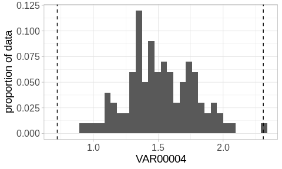

### Setting Bounds

Upon first evaluation of numeric variable distributions, you may find that you want to assert min and/or max bounds to remove outliers. This can be done in the config as follows:

```yaml
VAR00004:
  name: "height"
  type: "numeric"
  canonical_name: "Standing Height (meters)"
  bounds:
    min: 1.0
    max: 2.2
```

You can then re-run `create.phenotype.report` and re-assess the histogram in the HTML report. You should see that the bounds have been applied.

#### Histogram of VAR00004 (Standing Height (meters)) Distribution

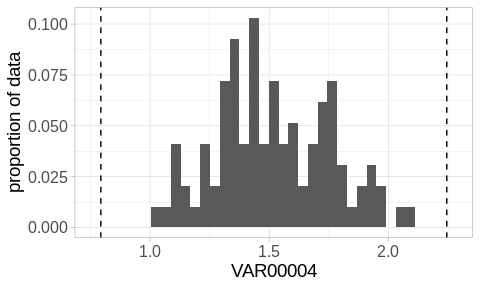

A table will also be emitted that tells you how many values are excluded by the bounds, as shown here:

Numeric bounds on VAR00004 (Standing Height (meters))

| Type | Value | Count |
| --- | --- | --- |
| minimum | 1.0 | 2 |
| maximum | 2.2 | 1 |

### Bimodal Numerics

Sometimes we have seen a bimodal distribution in some numeric variables. This may be expected, for example in some anthropometric measurements amongst male/female subjects. However, this can also be indicative of different collection centers or research associates collecting data in different units. This will often be evident in the HTML report generated by `create.phenotype.report` when looking at the histogram.

```yaml
VAR00005:
  name: "waist_circumference"
  type: "numeric"
  canonical_name: "Waist Circumference (centimeters)"
```

#### Histogram of VAR00005 (Waist Circumference (centimeters)) Distribution

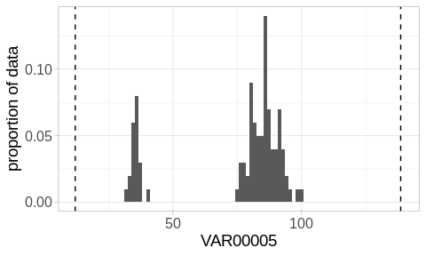

In this case, perhaps a subset of research associates or sites collected this data in inches instead of centimeters. You can address this in one of several ways, including 1) setting an upper or lower bound, or 2) creating a derived variable with a more sophisticated operation to attempt to perform a unit conversion. We explored setting bounds above, so here is an example of creating a derived variable for this scenario:

```yaml
derived:
  VAR00005_corrected:
    name: "Waist circumference with units harmonized"
    type: "numeric"
    code: |
      res <- VAR00005
      res[res < 50] <- res[res < 50] * 2.54
      res
```

In the configuration above, we have created a new derived variable based on the original waist circumference stored in VAR00005. The text in the `code` block is executed in an isolated environment and does not affect the underlying original data. You have access to all of the variables in the dataset as vectors, labeled as their user-defined names (e.g. “VAR00005”). Note the pipe symbol following `code:` in the example above. The YAML specification defines a variety of symbols to allow interpretation of multiline strings/ string literals; please see the [YAML multiline documentation](https://yaml-multiline.info/) for more information.

#### Histogram of VAR00005_corrected (Waist circumference with units harmonized) Distribution

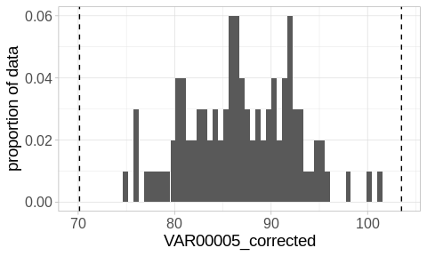

### Categorical Variables

Categorical variables are useful when you have a variable with a relatively small set of possible response values. One example could be sex, as shown below. Sometimes categorical variables are well-structured and conform easily to specific levels; other times you may find a wide variety of values that could be sorted into categorical levels. You can use alternate patterns, which are treated as [regular expressions](https://r4ds.had.co.nz/strings.html#matching-patterns-with-regular-expressions), to set definitions for levels.

```yaml
VAR00006:
  name: "sex"
  canonical_name: "Sex"
  type: "categorical"
  levels:
    "1":
      name: "Male"
      alternate_patterns:
        - "^male$"
        - "^[Mm]$"
    "2":
      name: "Female"
      alternate_patterns:
        - "^female$"
        - "^[Ff]$"
```

The `name` for each level will be shown in a table in the HTML report, along with counts for each value matching that level (or an alternate pattern for that level). Values that do not match the expected level names or patterns will be listed in an additional table, and you might want to revisit the configuration to add them as alternate patterns if appropriate. Otherwise, they will be treated as NA values.

Summary of VAR00006 (Sex)

| Value | Summary statistics |
| --- | --- |
| Male | 41 |
| Female | 41 |
| NA | 18 |

Values that were not consistent with categorical format.

| VAR00006 | Count |
| --- | --- |
| alive | 9 |
| panda | 9 |

### Adding Variable-Specific Aliases for `NA`

Some variables may contain values that are not recognized as global `NA` aliases within the package. You might see things like “not measured”, “cannot remember”, and other creative responses that can safely be mapped to `NA`. You can specify aliases for those values in the YAML config as follows:

```yaml
VAR00007:
  name: "fruit"
  canonical_name: "Do you eat fruit?"
  type: "categorical"
  levels:
    "1":
      name: "yes"
    "2":
      name: "no"
  na-values:
    - "not answered"
```

Some common `NA` values are ambiguous. For example, “none” can be an `NA` value, or it can be meaningful, depending on the question asked and the expected responses. This is why we allow `NA` configuration on a per-variable basis, and not on a global basis.

### Reporting Dependencies

You can use dependencies in the YAML configuration file to check for consistency across related variables. We have two related example variables here, one about whether a subject eats fruit, and another about which fruit is preferred.

```
#>         fruit preferred fruit
#>           yes           apple
#>  not answered      strawberry
#>            no      strawberry
#>            no      strawberry
#>           yes           apple
#>  not answered            pear
#>           yes            pear
#>           yes            pear
#>  not answered            <NA>
#>           yes           apple
#>           yes      strawberry
#>           yes      strawberry
#>           yes      strawberry
#>  not answered      strawberry
#>            no           apple
#>           yes      strawberry
#>           yes           apple
#>           yes           apple
#>           yes      strawberry
#>           yes            pear
#>  [ reached 'max' / getOption("max.print") -- omitted 80 rows ]
```

You might expect that subjects who list a preferred fruit should have also answered “yes” to the question of whether they eat fruit. You can check this by creating a dependency in the configuration:

```yaml
VAR00008:
  name: "preferred fruit"
  canonical_name: "What is your preferred fruit?"
  type: "categorical"
  levels:
    "1":
      name: "apple"
    "2":
      name: "pear"
    "3":
      name: "strawberry"
  dependencies:
    "1":
      name: "must eat fruit to have a preferred fruit"
      condition: |
        is.na(VAR00008) |
        (!is.na(VAR00007) & VAR00007 == "yes")
```

Let’s take a look at the summary tables for each of the two variables that we’ve defined as having a dependency relationship. You can find tables like the ones excerpted here in the HTML report output after running the package.

Summary of VAR00007 (Do you eat fruit?)

| Value | Summary statistics |
| --- | --- |
| yes | 61 |
| no | 26 |
| NA | 13 |

Summary of VAR00008 (What is your preferred fruit?)

| Value | Summary statistics |
| --- | --- |
| apple | 27 |
| pear | 32 |
| strawberry | 31 |
| NA | 10 |

What if some subjects have violated the assumption we made earlier, that you must eat fruit in order to have a preferred fruit? The dependency written above in the configuration file will report out the number and ID of subjects who violate the `condition` defined. In this case, we are looking for subjects who either have an `NA` response for VAR00008, or who have a non-`NA` response to VAR00008 and an affirmative response to VAR00007. That is, we are confirming that subjects who listed a preferred fruit have replied “yes” to whether they eat fruit. Subjects who violate this condition will be listed out, both in the form of a count and a list of subject IDs, in the HTML report, and as shown below.

#### Dependency tracking

Results of cross-variable dependency tests.

[output not shown]

To get an overview of the expected relationships between the levels of two variables, you may want to use the `table_comparisons` flag in the configuration file. It takes a list of additional variable names and generates pairwise contingency tables and emits them into the HTML report. For example, if you wanted to explore the relationships between the two fruit-related variables we’ve been using in this section, you would configure as follows:

```yaml
VAR00008:
  name: "preferred fruit"
  canonical_name: "What is your preferred fruit?"
  type: "categorical"
  levels:
    "1":
      name: "apple"
    "2":
      name: "pear"
    "3":
      name: "strawberry"
  dependencies:
    "1":
      name: "must eat fruit to have a preferred fruit"
      table_comparisons:
        - VAR00007
      condition: |
        response.depends.on.yes(VAR00008, VAR00007)
```

Contingency table for VAR00007 ( (Do you eat fruit?)) [rows] versus VAR00008 [columns]

|  | apple | pear | strawberry | NA |
| --- | --- | --- | --- | --- |
| yes | 17 | 21 | 18 | 5 |
| no | 9 | 7 | 6 | 4 |
| NA | 1 | 4 | 7 | 1 |

Evaluation of the contingency table can help guide you as to whether responses to a dependent variable should depend on non-NA values, “yes” values, other aliases, etc.

### Enforcing Dependencies

If you’ve detected dependency failures, what are the next steps? You might want to filter out these noisy, potentially erroneous responses. Depending on the upstream data processing stream, this might be indicative of a variety of issues: differences in the way a question was posed to subjects by different research associates, transposition in column or row values, inaccurate transcription, etc. You can tell `process.phenotypes` how to handle dependency failures by setting additional yaml flags in the dependency block. In the example below, we have added a flag that will, for any subject that fails the dependency condition, set the value in the listed variables to `NA`. Note that this does not happen automatically, even for the variable block you’re within in the config.

```yaml
VAR00008:
  name: "preferred fruit"
  canonical_name: "What is your preferred fruit?"
  type: "categorical"
  levels:
    "1":
      name: "apple"
    "2":
      name: "pear"
    "3":
      name: "strawberry"
  dependencies:
    "1":
      name: "must eat fruit to have a preferred fruit"
      condition: |
        response.depends.on.yes(VAR00008, VAR00007)
      exclude_on_failure:
        - VAR00007
        - VAR00008
        - VAR_other_fruit
        - VAR_other_relevant_variable
```

Alternatively, for particularly toxic dependency failures, you may want to set all variables to `NA` for a subject that fails the dependency check. For example, if you find that date of birth and reported age of subject are wildly discrepant, and you suspect that this is indicative of a loss of dataset integrity, you might want to exclude all subjects that fail a dependency check of similarity between reported age and age calculated from date of birth. The flag shown below will, for all subjects failing the check, set all values to `NA` for every variable except the one flagged in the yaml configuration as the subject ID.

```yaml
VAR00008:
  name: "preferred fruit"
  canonical_name: "What is your preferred fruit?"
  type: "categorical"
  levels:
    "1":
      name: "apple"
    "2":
      name: "pear"
    "3":
      name: "strawberry"
  dependencies:
    "1":
      name: "must eat fruit to have a preferred fruit"
      condition: |
        response.depends.on.yes(VAR00008, VAR00007)
      exclude_all_on_failure: yes
```

### Free Text Entries

For variables where you’re not sure what type they might be, or if you want extremely minimal cleaning/processing, you can set the type to `string`. For example, free text entries containing physician notes can be set to type `string` and subsequently parsed as derived variables that indicate the presence of important keywords within the notes variable.

```yaml
VAR00009:
  name: "letters"
  type: "string"
  suppress_reporting: yes
  suppress_output: yes
```

Note that by default, if the total number of unique entries in a variable exceeds 33% of the total number of subjects, reporting will be suppressed (so you don’t end up with an HTML report that’s miles long). This can be configured via a parameter for `create.phenotype.report`.

Additionally, if your free text contains information that you’d rather not display in the report (e.g. phone numbers, etc.), you can suppress reporting using the `suppress_reporting` boolean shown in the config example above. This will not alter the content of the variable.

On the other hand, if you have variables that should not be included in the cleaned output phenotype matrix (e.g. first and last names, social security numbers, etc.), you can use the `suppress_output` flag in addition to `suppress_reporting`. This will prevent both printing to the report, and it will cause the variable to be emitted with all values set to `NA`.

### Blood Pressure Measurements

While blood pressure values are often recorded as systolic and diastolic separately, sometimes they are given as a single entry, e.g. “120/90 mm Hg”. If you have blood pressure measurements in this format, this variable type may be useful. Variables of this type allow a wide range of potential format issues, and attempt to harmonize them to SBP/DBP. Subsequently, derived variables can be created to isolate systolic and diastolic blood pressure values.

```yaml
VAR00011:
  name: "bloodpressure"
  type: "bp"
```

```
#>       before   after
#>   133  , 131 133/131
#>     234 ,137 234/137
#>   184  /  79  184/79
#>   230  - 107 230/107
#>     248 ,143 248/143
#>     170/  60  170/60
#>       184,91  184/91
#>  144  ,  117 144/117
#>      237 ,63  237/63
#>    211,  132 211/132
#>   206 -  130 206/130
#>       125-96  125/96
#>     201,  79  201/79
#>    228 ,  88  228/88
#>     119  -57  119/57
#>    225-  144 225/144
#>      140 ,54  140/54
#>      143/115 143/115
#>   139  , 135 139/135
#>    155  ,100 155/100
#>  [ reached 'max' / getOption("max.print") -- omitted 80 rows ]
```